# M4 Lab

Vanessa Hong

```r
library(tidyverse)

library(tidyverse)
if(!require(emmeans)){install.packages("emmeans")
  library(emmeans)} #this line installs the package only if you don't already have it installed
if(!require(car)){install.packages("car")
  library(car)}
```

# Part 1: Tumor Growth

## Data Management

**Load the data into R using the load() function.**

```r
# load data
load("C:/Users/vanes/Documents/SCHOOL/comp_bio/BIOST2041/Data/tumor_growth.RData", verbose = T)
```

```
## Loading objects:
##   tumor
```

```r
head(tumor)
```

| Group | ID | Size |
| --- | --- | --- |
| 1 | 101 | 1678.3 |
| 1 | 102 | 1563.7 |
| 1 | 103 | 2405.7 |
| 1 | 104 | 1964.2 |
| 1 | 105 | 2162.8 |
| 1 | 106 | 2125.1 |

### Creating new factor variable

**Create a new factor variable to label the treatment groups (1 = control, 2 = drug only, 3 = radiation only, 4 = drug + radiation). We are going to use this variable as our grouping variable in the ANOVA model below. Why is it important that we use the categorical version and not the numeric version in ANOVA?**

```r
# create new factor variable
tumor <- tumor %>%
  mutate(Treatment = factor(Group,
                            levels = c(1, 2, 3, 4),
                            labels = c("control", "drug only", "radiation only", "drug + radiation")))

head(tumor)
```

| Group | ID | Size | Treatment |
| --- | --- | --- | --- |
| 1 | 101 | 1678.3 | control |
| 1 | 102 | 1563.7 | control |
| 1 | 103 | 2405.7 | control |
| 1 | 104 | 1964.2 | control |
| 1 | 105 | 2162.8 | control |
| 1 | 106 | 2125.1 | control |

Response: ANOVA compares distinct group means, so continuous data should not be used in ANOVA tests, and if we use numerical values, R would interpret these numbers as continuous variables. Turning these values into factors ensures the variables are discrete.

## Descriptive Statistics

Display an appropriate numerical summary for tumor size by treatment group. Create appropriate visualizations to display the distribution of tumor size by treatment group. Comment on what you see.

```r
# summary statistics and visualization
tumor %>%
  group_by(Treatment) %>%
  summarise(n = n(),
            sample_mean = mean(Size),
            sample_sd = sd(Size),
            sample_var = var(Size))
```

| Treatment | n | sample_mean | sample_sd | sample_var |
| --- | --- | --- | --- | --- |
| control | 8 | 2067.287 | 309.5128 | 95798.18 |
| drug only | 10 | 1787.750 | 504.5335 | 254554.04 |
| radiation only | 10 | 1890.320 | 420.8880 | 177146.69 |
| drug + radiation | 9 | 1130.644 | 712.1898 | 507214.33 |

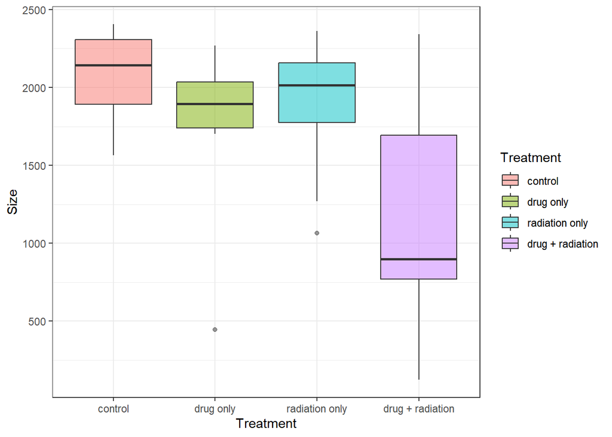

```r
# visualization
tumor %>%
  ggplot(aes(x = Treatment, y = Size, fill = Treatment)) +
  geom_boxplot(alpha = .5) +
   theme_bw()
```

Response: Looking at the box plots, the control, drug only, and radiation only treatments all have somewhat close tumor size means (2067.287, 1787.750, 1890.320, respectively) and ranges (around 309-504 SD). The drug + radiation treatment has a significantly smaller mean sample size of 1130.644, and a much wider SD of around 712. The distributions are relatively normal.

## ANOVA

**Perform one-way ANOVA (with appropriate post-hoc comparisons if warranted) using an 0.05 significance level to see if there was a treatment effect on tumor size. In your write-up, include the following:**

- **For the overall ANOVA F test…**
  - **descriptions of the null and alternative hypotheses in words (not symbols) (1 pt)**
  - **check the conditions to be able to use ANOVA (1 pt)**
  - **the p-value, decision, and conclusion (1 pt)**
- **(0.5 pts) A table of post-hoc pairwise treatment comparisons indicating which are statistically significant, if applicable.**

**(1 pt) Summarize your findings from this section to address the primary research question (which treatment[s] yielded the best outcome).**

### Null and alternative hypotheses

Response: H0: There is no difference in mean tumor size in all four treatment groups.

HA: At least one treatment group has a significantly different mean tumor size.

### Check Conditions

```r
# check conditions
table(tumor$Treatment)
```

```
##
##          control        drug only   radiation only drug + radiation
##                8               10               10                9
```

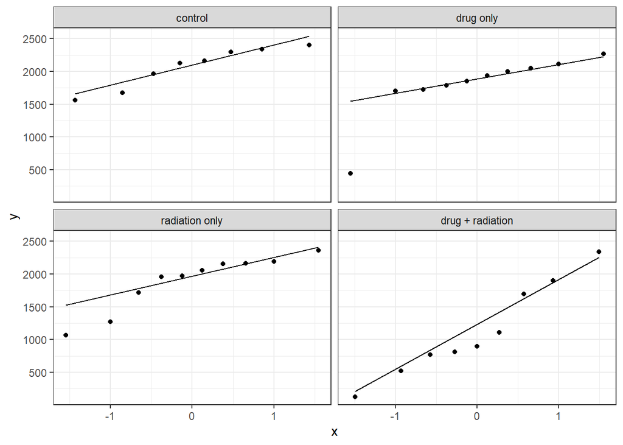

```r
tumor %>%
  ggplot(aes(sample = Size)) +
  geom_qq() +
  geom_qq_line() +
  facet_wrap( ~ Treatment) +
  theme_bw()
```

```r
tumor %>%
  group_by(Treatment) %>%
  summarise(n = n(),
            sample_var = var(Size))
```

| Treatment | n | sample_var |
| --- | --- | --- |
| control | 8 | 95798.18 |
| drug only | 10 | 254554.04 |
| radiation only | 10 | 177146.69 |
| drug + radiation | 9 | 507214.33 |

Response:

Conditions:

- Independent groups: Groups are assumed to be independent.
- Random sample: Groups assumed to be randomly sampled.
- N > 30 in each group or normal distribution for outcome variable in each group: N is very small for each group, < 11. They look relatively normal.
- Equal variances across groups: variances are not equal.

```r
# run anova
# recall to run anova we first fit a model using
# model <- lm(outcome ~ predictor, data = data_name)
# then we get the analysis of variance table using anova(model)
# fit model
anova_model <- lm(Size ~ Treatment, data = tumor)
summary(anova_model)
```

```
##
## Call:
## lm(formula = Size ~ Treatment, data = tumor)
##
## Residuals:
##      Min       1Q   Median       3Q      Max
## -1342.55  -231.84    68.58   269.28  1212.36
##
## Coefficients:
##                           Estimate Std. Error t value Pr(>|t|)
## (Intercept)                 2067.3      180.6  11.445 4.97e-13 ***
## Treatmentdrug only          -279.5      242.3  -1.153 0.256996
## Treatmentradiation only     -177.0      242.3  -0.730 0.470395
## Treatmentdrug + radiation   -936.6      248.3  -3.773 0.000638 ***
## ---
## Signif. codes:  0 '***' 0.001 '**' 0.01 '*' 0.05 '.' 0.1 ' ' 1
##
## Residual standard error: 510.9 on 33 degrees of freedom
## Multiple R-squared:  0.3394, Adjusted R-squared:  0.2794
## F-statistic: 5.653 on 3 and 33 DF,  p-value: 0.00307
```

```r
# anova table
anova(anova_fit)
```

[output not shown]

Response: p-value: 0.00307. We reject the null hypothesis. There is a statistically significant difference in the tumor size in these treatment groups.

### Post-hoc comparisons

```r
# post-hoc comparisons if appropriate
posthoc <- emmeans(anova_model, pairwise ~ Treatment, adjust = "none")
posthoc$contrasts
```

```
##  contrast                            estimate  SE df t.ratio p.value
##  control - drug only                      280 242 33   1.153  0.2570
##  control - radiation only                 177 242 33   0.730  0.4704
##  control - (drug + radiation)             937 248 33   3.773  0.0006
##  drug only - radiation only              -103 228 33  -0.449  0.6564
##  drug only - (drug + radiation)           657 235 33   2.799  0.0085
##  radiation only - (drug + radiation)      760 235 33   3.236  0.0028
```

```r
# adding bonferroni correction to adjust for multiple comparisons
posthoc_b <- emmeans(anova_model, pairwise ~ Treatment, adjust = "bonferroni")
posthoc_b$contrasts
```

```
##  contrast                            estimate  SE df t.ratio p.value
##  control - drug only                      280 242 33   1.153  1.0000
##  control - radiation only                 177 242 33   0.730  1.0000
##  control - (drug + radiation)             937 248 33   3.773  0.0038
##  drug only - radiation only              -103 228 33  -0.449  1.0000
##  drug only - (drug + radiation)           657 235 33   2.799  0.0509
##  radiation only - (drug + radiation)      760 235 33   3.236  0.0165
##
## P value adjustment: bonferroni method for 6 tests
```

### Summary

**Summarize your findings from this section to address the primary research question (which treatment[s] yielded the best outcome).**

Response:

The ANOVA results show that treatment has a significant effect on tumor size (F-statistic = 5.65, p = 0.003). Post-hoc, the p-values of the Bonferroni comparisons show that the drug + radiation treatment combination produced significantly smaller tumors than several of the other groups (p-val = 0.0038). There were no significant differences between control, drug only, or radiation only treatments. Therefore, the drug + radiation treatment yielded the best outcome.

## Kruskal-Wallis

**Perform a Kruskal-Wallis test using a significance level of 0.05 to see if there was a treatment effect on tumor size. In your write-up, include the following:**

- **descriptions of the null and alternative hypotheses in words (not symbols) (0.5 pts)**
- **check the conditions to be able to use the test (0.5 pts)**
- **the p-value, decision, and conclusion (0.5 pts)**

**Comment on whether this is in agreement with the results from ANOVA or not.**

### Null and alternative hypotheses

Response: H0: the median of the tumor sizes is the same across all tumor groups.

HA: At least one group has a different median tumor size.

### Conditions

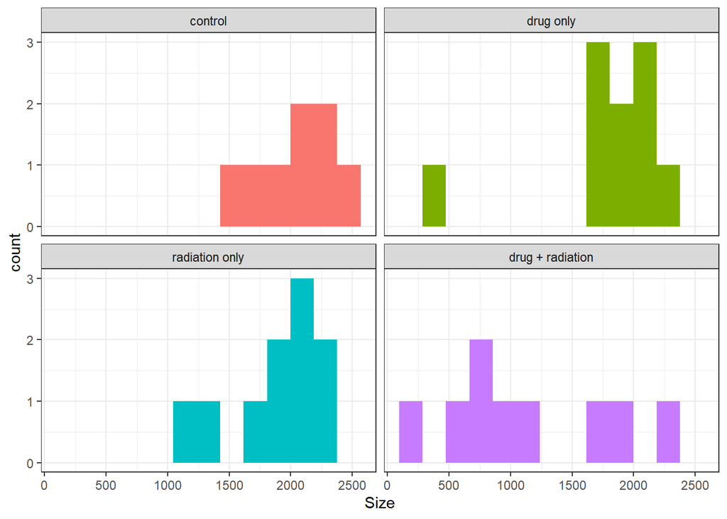

```r
# code to check conditions

# check for similar distributions
tumor %>%
  ggplot(aes(x = Size)) +
  geom_histogram(aes(fill = Treatment), bins = 13) +
  theme_bw() +
  facet_wrap( ~ Treatment) +
  theme(legend.position = "none")
```

Response: The data is assumed independent and randomly sampled, the dependent variable (Size) is continuous and the grouping variable (Treatment) is categorical. The data are also indeed in non-normal distributions.

### Run Kruskal-Wallis

```r
# kruskal-wallis test
kruskal.test(Size ~ Treatment, data = tumor)
```

```
##
##  Kruskal-Wallis rank sum test
##
## data:  Size by Treatment
## Kruskal-Wallis chi-squared = 9.5212, df = 3, p-value = 0.02311
```

Response: p-value = 0.02311, reject the null hypothesis. There is a statistically significant difference in median tumor sizes among the four treatment groups, so at least one treatment group differs from the others in terms of tumor growth.

### Do the results agree with ANOVA?

Response: Yes, both the ANOVA and the Kruskal-Wallis test have low enough p-values to conclude that there is a statistically significant difference in tumor sizes amongst the four treatment groups.

# Part 2: Intubation

## Data Management

**Load the data into R using the load() function. Filter the data to only include those with a successful first intubation attempt (attempt1_S_F ==1). For the rest of this assignment, you will only need the variables ‘BMI’ (patient’s body mass index) and ‘ease’ (ease of intubation).**

```r
# import data
load("C:/Users/vanes/Documents/SCHOOL/comp_bio/BIOST2041/Data/Laryngoscope.Rdata", verbose = T)
```

```
## Loading objects:
##   laryngoscope
```

```r
# filter data
lary <- laryngoscope %>%
  filter(attempt1_S_F == 1) %>%
  select(BMI, ease)
head(lary)
```

|  | BMI | ease |
| --- | --- | --- |
| 1 | 56.2 | 5 |
| 2 | 44.6 | 20 |
| 3 | 61.0 | 20 |
| 4 | 44.0 | 2 |
| 5 | 44.0 | 10 |
| 6 | 41.9 | 60 |

## Descriptive Statistics

**Create an appropriate visualization and numerical summary to display the relationship between BMI and ease of intubation. Comment on what you see.**

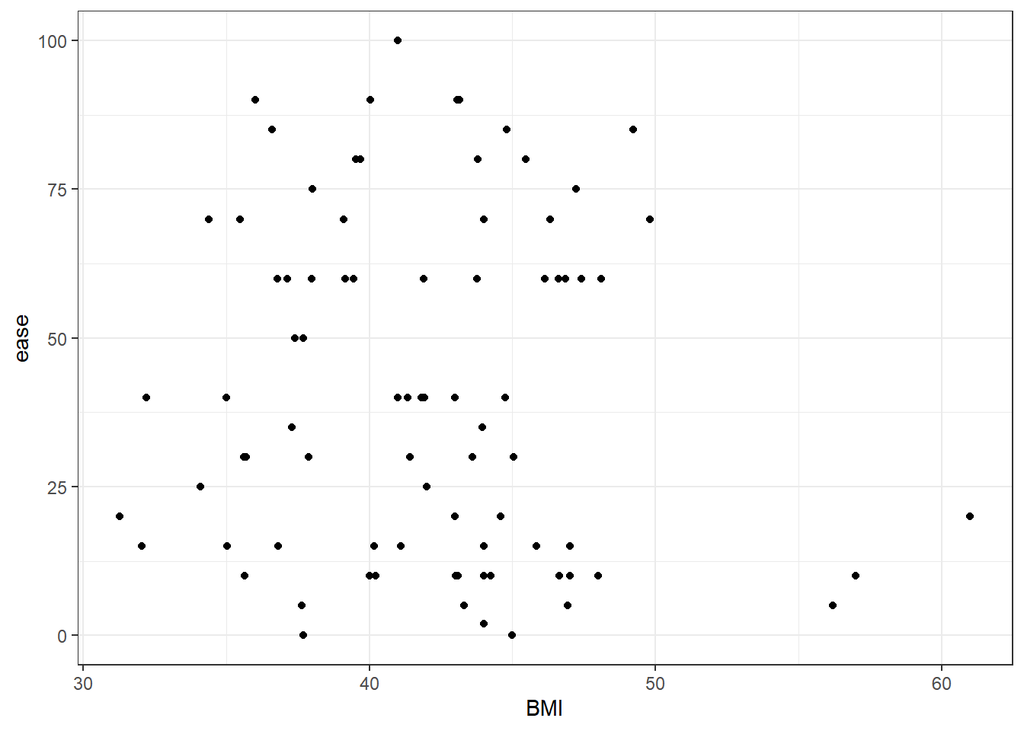

```r
# summary statistics and visualization

# visualize
lary %>%
  ggplot(aes(x = BMI, y = ease)) +
  geom_point() +
  theme_bw()
```

```r
# fit model
model <- lm(ease ~ BMI, data = lary)
# summary of model
summary(model)
```

```
##
## Call:
## lm(formula = ease ~ BMI, data = lary)
##
## Residuals:
##     Min      1Q  Median      3Q     Max
## -42.782 -27.106  -5.086  22.300  58.969
##
## Coefficients:
##             Estimate Std. Error t value Pr(>|t|)
## (Intercept)  62.7805    24.7642   2.535   0.0131 *
## BMI          -0.5305     0.5848  -0.907   0.3669
## ---
## Signif. codes:  0 '***' 0.001 '**' 0.01 '*' 0.05 '.' 0.1 ' ' 1
##
## Residual standard error: 28.41 on 84 degrees of freedom
##   (2 observations deleted due to missingness)
## Multiple R-squared:  0.009702,   Adjusted R-squared:  -0.002088
## F-statistic: 0.8229 on 1 and 84 DF,  p-value: 0.3669
```

Response: There does not appear to be correlation between the points. In the fit model summary, the p-value is 0.3669, indicating very poor correlation.

## Linear Regression

**Create a linear regression model with the variables BMI (x) and ease (y) (a scale from 0-100 with higher numbers indicating more difficult intubations) to address this. Show your model output. Use a 0.05 significance level for any hypothesis tests.**

```r
# fit model
# again here we use lm(y ~ x, data = data_name)

model <- lm(ease ~ BMI, data = lary)
# summary of model
summary(model)
```

```
##
## Call:
## lm(formula = ease ~ BMI, data = lary)
##
## Residuals:
##     Min      1Q  Median      3Q     Max
## -42.782 -27.106  -5.086  22.300  58.969
##
## Coefficients:
##             Estimate Std. Error t value Pr(>|t|)
## (Intercept)  62.7805    24.7642   2.535   0.0131 *
## BMI          -0.5305     0.5848  -0.907   0.3669
## ---
## Signif. codes:  0 '***' 0.001 '**' 0.01 '*' 0.05 '.' 0.1 ' ' 1
##
## Residual standard error: 28.41 on 84 degrees of freedom
##   (2 observations deleted due to missingness)
## Multiple R-squared:  0.009702,   Adjusted R-squared:  -0.002088
## F-statistic: 0.8229 on 1 and 84 DF,  p-value: 0.3669
```

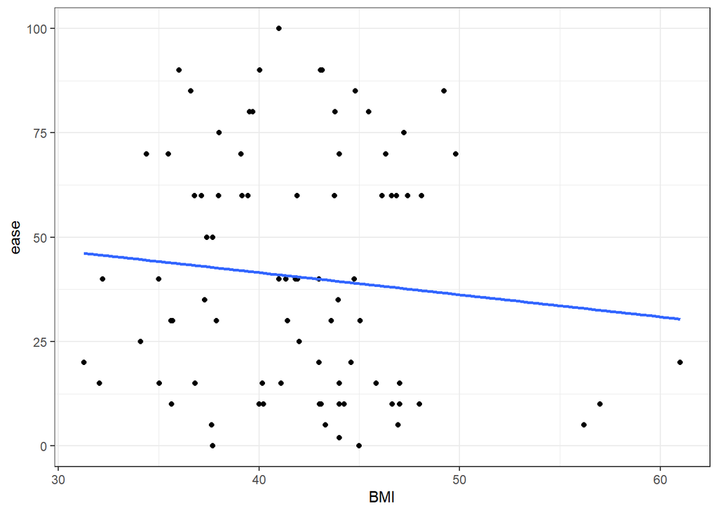

```r
# add standard error to this
lary %>%
  ggplot(aes(x = BMI, y = ease)) +
  geom_point() +
  theme_bw() +
  geom_smooth(method = "lm", se = F)
```

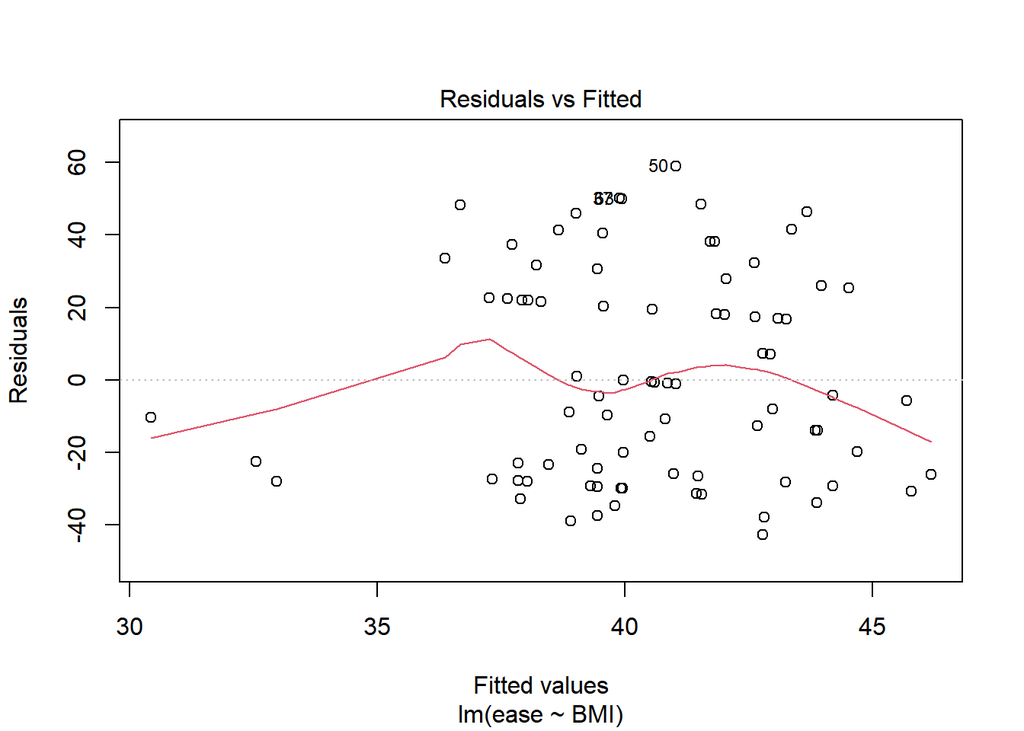

```r
# residual plots
# residual vs fitted values
# we can use this to check equal variance and linearity
plot(model, which = 1)
```

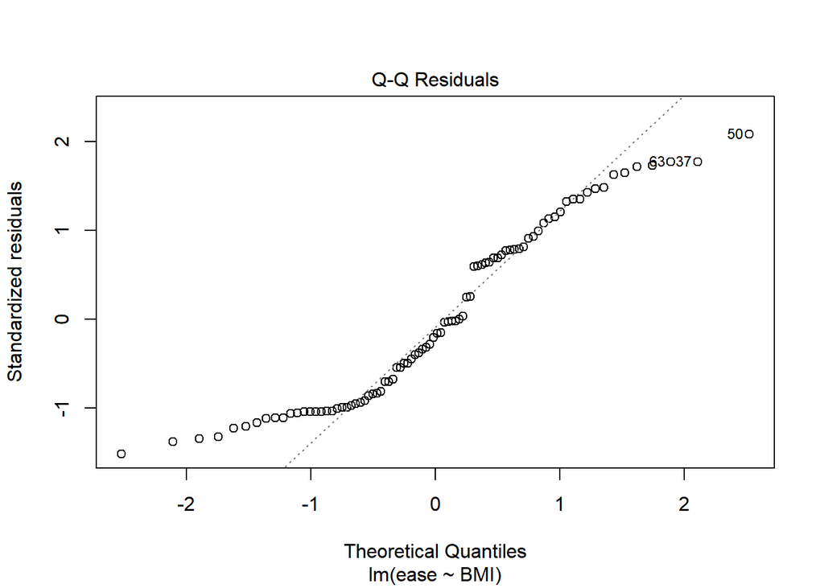

```r
# qq plot of residuals
plot(model, which = 2)
```

### Estimated regression model

Response: yhat = 62.78 + (-0.5305)*BMI

### Slope interpretation:

Response: There is a very slight negative correlation between increasing BMI and ease of intubation.

### Hypothesis test

Response: p-val = 0.3669, thus we fail to reject the null. There is not enough evidence to conclude a statistically significant correlation between increasing BMI and ease of intubation.

### Predicted value for BMI = 35

**Estimate the ease of intubation for a patient with a BMI of 35 (you do not need to calculate the interval for this estimate)**

```r
# predicted y for BMI = 35
predict(model, newdata  = data.frame(BMI = 35))
```

```
##        1
## 44.21411
```

```r
# 44.21411
```

Response: The predicted value at BMI = 35 is 44.21411.

### Summary

**Summarize your findings from this section to whether BMI is a good predictor of ease of intubation**

Response: BMI is not a good indicator for ease of intubation. There is a very slight negative correlation between these two variables, but it is not statistically significant enough (p-value = 0.3669) to reject the null hypothesis (that there is no correlation between BMI and ease of intubation).